# Doppler Shift

## McEwen, © 2025 | All Rights Reserved | Distribution Prohibited

### version 1.0, 2025

**This is a first version. It is a work in progress. Please report any errors or typos.**

## What is the Doppler shift?

You most likely have experienced the Doppler shift when an ambulance passes by you with the siren on. As the ambulance approaches you, you hear a constant high-pitched siren. When the ambulance passes you and moves away from you, you hear a constant lower-pitched siren.

The Doppler shift is the alteration of the observed frequency due to either the source moving, or the observer moving, or both source and observer moving. The observed shift in frequency is dependent on the relative velocity of the source and observer.

**Problem 1**

What is the quality of the wave that is associated with the pitch of a sound wave?

**Solution**

The frequency of the wave is associated with the pitch of a sound wave. Higher frequencies correspond to higher-pitched sounds, while lower frequencies correspond to lower-pitched sounds.

**Problem 2**

Juan stands at the 35 yard line and throws a football at 25 mph to Melissa who is running towards Juan at 10 mph. What is the velocity of the ball in Melissa's frame of reference?

**Solution**

In Melissa's frame of reference, she is stationary and everything else is moving relative to her. Since Melissa is running towards Juan at 10 mph, and the ball is thrown at 25 mph towards her, the relative velocity of the ball in Melissa's frame is:

$$v_{\text{ball, Melissa}} = 25 \text{ mph} + 10 \text{ mph} = 35 \text{ mph}$$

The ball appears to approach Melissa at 35 mph.

**Problem 3**

Huy runs to the right at a constant 20 mph. Robert runs to the right at a constant 23 mph. What is the relative velocity between Huy and Robert?

**Solution**

Since both are running in the same direction (to the right), the relative velocity is the difference in their speeds:

$$v_{\text{relative}} = 23 \text{ mph} - 20 \text{ mph} = 3 \text{ mph}$$

Robert is moving 3 mph faster than Huy (to the right in Huy's frame), or equivalently, Huy is moving 3 mph slower than Robert (to the left in Robert's frame).

**Problem 4**

Beth runs to the left at a constant 20 mph. Abdul runs to the right at a constant 23 mph. What is the relative velocity between Beth and Abdul?

**Solution**

Since Beth and Abdul are running in opposite directions, their relative velocity is the sum of their speeds:

$$v_{\text{relative}} = 20 \text{ mph} + 23 \text{ mph} = 43 \text{ mph}$$

In Beth's frame, Abdul is approaching at 43 mph. In Abdul's frame, Beth is approaching at 43 mph.

```python
import numpy as np
%matplotlib inline
import matplotlib.pyplot as plt
from matplotlib import animation
from IPython.display import HTML

from wave_animations import animate_wavefront, animate_wavefront_doppler
```

## Example of stationary source and stationary observer

Suppose we have a wave source at $x=0~\text{m}$. Suppose Maria stands at $x=10~\text{m}$. Maria will measure the frequency of the wave by measuring the time it takes for the wave to repeat itself. Maria can mark any point on the wave to observe, but a natural point on the wave for Maria to observe is the wave crest. The animation below illustrates the situation. The top panel shows a wave traveling to the right. The location of two wave crests is marked with a blue and red vertical line. The source of the wave is at $x=0$, while Maria stands at $x=10~\text{m}$. The second panel (bottom) removes the wave and leaves only the two marked wave crests. (We remove the wave because the wave is continuous and it is beneficial to just examine one particular spot of the wave.) Maria is marked with a red diamond and the source is marked with a green diamond. Maria will start her stopwatch when the wave crest marked in blue passes her. She will stop her stopwatch when the wave crest marked in red passes her. The time she records will be the period. She will calculate the frequency as $f_o=1/T$, where the $o$ subscript stands for observer.

**When will Maria make her recordings?**

Suppose the wave crest marked in blue is emitted from the source at $t=0$. Maria will observe this wave crest at $d/v$ where $d=10~\text{m}$ and $v$ is the wave speed; this is the time it takes the signal to travel from the source to the observer. The wave crest marked in red will be emitted one period after the first, so the wave crest in red is emitted at $t=T$. Maria will record the second wave crest at $T + d/v$.

In general, the time that an observer measures a signal from a moving source is $t + d/v$, where $d$ is the distance from the source to the observer and $v$ is the speed of the wave.

**Problem 5**

A wave moves to the right with wave parameters: $A=1~\text{mm}$, $\lambda=10~\text{cm}$, $T=0.5~\text{s}$. The wave is sourced at $x=0~\text{m}$. Yu stands at $x=2~\text{m}$ from the source. The first wave crest is emitted at $t=0$. At what time will Yu observe the first and second wave crests?

**Solution**

First, we need to find the wave speed: $$v = \frac{\lambda}{T} = \frac{10~\text{cm}}{0.5~\text{s}} = \frac{0.1~\text{m}}{0.5~\text{s}} = 0.2~\text{m/s}$$

The first wave crest is emitted at $t=0$ and travels a distance $d=2~\text{m}$ to reach Yu. The time when Yu observes the first crest is: $$t_1 = \frac{d}{v} = \frac{2~\text{m}}{0.2~\text{m/s}} = 10~\text{s}$$

The second wave crest is emitted at $t=T=0.5~\text{s}$. Yu will observe it at: $$t_2 = T + \frac{d}{v} = 0.5~\text{s} + 10~\text{s} = 10.5~\text{s}$$

**Problem 7**

In this notebook, we are considering sound waves. The animations in the notebook show traveling transverse waves. This is typical in a textbook to display sound waves like this. What kind of wave is a sound wave? What do the oscillations in the plots or animations represent?

**Solution**

Sound waves are **longitudinal waves**, not transverse waves.

In a longitudinal wave, the oscillations of the medium (air molecules) occur parallel to the direction of wave propagation. Air molecules oscillate back and forth along the direction the sound travels, creating regions of compression (high pressure) and rarefaction (low pressure).

The transverse wave animations in this notebook are a **visual representation** of the sound wave, where:

- The vertical displacement in the animation represents the **displacement of air molecules** from their equilibrium positions (or equivalently, the pressure variation)
- The horizontal axis represents position along the direction of wave travel
- The wave crests correspond to compressions (regions where air molecules are pushed together)
- The wave troughs correspond to rarefactions (regions where air molecules are spread apart)

This transverse representation is used because:

1. It's easier to visualize than trying to animate molecules moving back and forth
2. The mathematics is identical—both longitudinal and transverse waves satisfy the same wave equation
3. It clearly shows wavelength, frequency, and wave propagation

**In reality:** If you could see air molecules during sound propagation, you would see them oscillating horizontally (parallel to the wave direction), bunching together and spreading apart, rather than moving up and down.

```python
anim=animate_wavefront()
HTML(anim.to_html5_video())
```

[video not shown]

### Source moving toward observer

**Note:** Our everyday experience and intuition inform us that the observed frequency is larger (higher pitch) than the source frequency. So, we should expect that result in our derivation (one way to check if we did it right).

Maria stands at a distance $d$ away from the source; in the animation $d=10~\text{m}$. The source is traveling toward Maria at a speed $v_s$. Maria measures the frequency of the observed wave by marking the time between observations of each wave crest. The experiment is set up so that when the source crosses $x=0$ the first wave crest is generated at time $t=0$.

- The first wave crest will travel a distance $d$ at a speed $v$ (the wave speed) and therefore Maria will log the first observation of the wave crest at $t_{1,o}= d/v$ (the time is marked with a numerical subscript to indicate first measurement of the wave and $o$ subscript to indicate observer).
- The second wave crest will be generated at time $t=T$, where $T$ is the period of the wave.
- At time $t=T$ the source has moved to location $x=v_s T$.
- The second wave crest will travel a distance $d-v_sT$ to reach Maria with a speed of $v$. The distance is shorter now because the source has moved. The time that Maria records the second observation is $t_{2,o}= T + (d-v_s T)/v$.

Maria will then take the difference in the two times to compute the observed period, which we will call $T_o$:

\begin{align} \begin{split} T_o & = t_{2,o} - t_{1,o} \\ & = T + \frac{d-v_s T}{v} - \frac{d}{v} \\ & = T\left( 1 - \frac{v_s}{v} \right) \\ & = T\left( \frac{v - v_s}{v} \right). \end{split} \end{align}

Maria computes the observed frequency by taking the reciprocal of the observed period:

\begin{align} f_o = \frac{v}{v-v_s} f. \end{align}

Note that the observed frequency is greater than the source frequency $f$. Also, the book by Knight denotes the above expression as $f_+$.

The situation is illustrated in the animation below. Again, the wave is removed and we only concentrate on the wave crests. The green square represents the moving source. The red diamond represents the stationary observer. The wave variables are the same as the animation above, i.e., same period, wavelength, and amplitude. You should observe that the time between arrivals of the red and blue wave crests is shorter than the animation above.

```python
anim=animate_wavefront_doppler()
HTML(anim.to_html5_video())
```

[video not shown]

### Source moving away from the observer

**Note:** Our everyday experience and intuition inform us that the observed frequency is smaller (lower pitch) than the source frequency.

Maria stands at a distance $d$ away from the source. The source is traveling away from Maria at a speed $v_s$. Maria measures the frequency of the observed wave by marking the time between observations of each wave crest. The experiment is set up so that when the source crosses $x=0$ the first wave crest is generated at time $t=0$.

- The first wave crest will travel a distance $d$ at a speed $v$ (the wave speed) and therefore Maria will log the first observation of the wave crest at $t_{1,o}= d/v$ (the time is marked with a numerical subscript to indicate first measurement of the wave and $o$ subscript to indicate observer).
- The second wave crest will be generated at time $t=T$, where $T$ is the period of the wave.
- At time $t=T$ the source has moved to location $x=-v_s T$ (the source is moving to the left).
- The second wave crest will travel a distance $d + v_sT$ to reach Maria with a speed of $v$. Therefore the time that Maria records the second observation is $t_{2,o}= T + (d + v_s T)/v$.

Maria will then take the difference in the two times to compute the observed period, which we will call $T_o$:

\begin{align} \begin{split} T_o & = t_{2,o} - t_{1,o} \\ & = T + \frac{d+ v_s T}{v} - \frac{d}{v} \\ & = T\left( 1 + \frac{v_s}{v} \right) \\ & = T\left( \frac{v + v_s}{v} \right). \end{split} \end{align}

Maria computes the observed frequency by taking the reciprocal of the observed period:

\begin{align} f_o = \frac{v}{v+v_s} f. \end{align}

Note that the observed frequency is less than the source frequency $f$. Also, the book by Knight denotes the above expression as $f_-$.

### Stationary source and moving observer

In this experiment the source is stationary, but Maria is moving toward the source with velocity $v_o$. We don't need to do much work here to get the correct expression. The first thing we should note is that the observed frequency will be larger than the source frequency, that is, we expect Maria to hear a higher pitch.

So, how do we obtain our expression without doing much work? Well, we move to Maria's frame of reference. In Maria's frame of reference, she is stationary, but the source is moving toward her at velocity $v_o$. But there is one more catch. Maria doesn't observe the wave to be traveling at $v$ but at $v + v_o$! Let's consider another example: your buddy throws a ball toward you at 30 mph, while you run toward your buddy at 10 mph. In your frame of reference the ball is moving toward you at 40 mph. Hopefully, that cleared it up for you.

Okay, so all we have to do is substitute $v_s \to v_o$ and $v \to v + v_o$ in the expression for $f_+$:

\begin{align} f_o = \frac{v + v_o}{v} f, \end{align}

this is our result for an observer moving toward a stationary source.

### Stationary source and moving observer

In this experiment the source is stationary, but Maria is moving toward the source with velocity $v_o$. The observed frequency will be larger than the source frequency—Maria will hear a higher pitch.

**Derivation:**

When the source is stationary, it emits wave crests separated by wavelength $\lambda = vT$, where $v$ is the wave speed and $T$ is the period.

Maria moves toward the source at speed $v_o$. From her perspective, she encounters the oncoming wave crests at a relative speed of $v + v_o$ (the wave approaches at $v$, and she moves toward it at $v_o$).

The time between successive wave crests passing Maria is: \begin{align} T_o = \frac{\lambda}{v + v_o} = \frac{vT}{v + v_o} \end{align}

Therefore, the observed frequency is: \begin{align} f_o = \frac{1}{T_o} = \frac{v + v_o}{vT} = \frac{v + v_o}{v} f, \end{align}

which confirms that the observed frequency is greater than the source frequency when the observer moves toward the source.

**Problem 8**

There are a few more examples we could work out. For these problems, think carefully about:

- Whether the observer is moving toward or away from the wave crests (affecting the relative speed at which crests are encountered)
- Whether the source is moving, which affects the spacing between wave crests
- Whether the observed frequency should be higher or lower than the source frequency
1. Suppose the source is stationary and Maria is moving away from the source at $v_o$. Show that the observed frequency is \begin{align} f_o = \frac{v - v_o}{v} f. \end{align}
2. Suppose the source is moving toward Maria with velocity $v_s$ and Maria is moving toward the source at $v_o$. Show that the observed frequency is \begin{align} f_o = \frac{v + v_o}{v-v_s} f. \end{align}
3. Suppose the source is moving toward Maria with velocity $v_s$ and Maria is moving away from the source at $v_o$. Show that the observed frequency is \begin{align} f_o = \frac{v - v_o}{v-v_s} f. \end{align}
4. We still have not exhausted all possible scenarios. What are some other scenarios and what are the formulas for the observed frequency?

**Hint for parts 1-3**

**General approach for combined motion:**

When both source and observer move, we need to account for two effects separately:

1. **Source motion** changes the wavelength of the wave:
   - If the source moves toward the observer at $v_s$, successive crests are emitted closer together
   - The wavelength becomes $\lambda' = (v - v_s)T$ (from our earlier derivation)
   - If the source moves away at $v_s$, then $\lambda' = (v + v_s)T$
2. **Observer motion** changes how quickly the observer encounters wave crests:
   - If the observer moves at $v_o$ toward the source, crests are encountered at relative speed $v + v_o$
   - If the observer moves away, the relative speed is $v - v_o$

Combine these: $T_o = \frac{\lambda'}{\text{relative speed}}$, then $f_o = 1/T_o$.

**Solution**

**Part 1:** Source stationary, Maria moving away at $v_o$

The source is stationary, so the wavelength is $\lambda = vT$.

Maria moves away from the source at $v_o$. The wave crests approach her at speed $v$, but she's moving away at $v_o$, so the relative speed at which she encounters crests is $v - v_o$.

The observed period is: $$T_o = \frac{\lambda}{v - v_o} = \frac{vT}{v - v_o}$$

The observed frequency is: $$f_o = \frac{1}{T_o} = \frac{v - v_o}{vT} = \frac{v - v_o}{v} f$$

The observed frequency is less than the source frequency, as expected.

**Part 2:** Source moving toward Maria at $v_s$, Maria moving toward source at $v_o$

From our earlier derivation, when the source moves toward the observer at $v_s$, the wavelength is: $$\lambda' = (v - v_s)T$$

Maria moves toward the source at $v_o$, so she encounters wave crests at relative speed $v + v_o$.

The observed period is: $$T_o = \frac{\lambda'}{v + v_o} = \frac{(v - v_s)T}{v + v_o}$$

The observed frequency is: $$f_o = \frac{1}{T_o} = \frac{v + v_o}{(v - v_s)T} = \frac{v + v_o}{v - v_s} f$$

The observed frequency is greater than the source frequency (both motions increase the frequency).

**Part 3:** Source moving toward Maria at $v_s$, Maria moving away from source at $v_o$

The source moves toward Maria at $v_s$, so the wavelength is: $$\lambda' = (v - v_s)T$$

Maria moves away from the source at $v_o$, so she encounters wave crests at relative speed $v - v_o$.

The observed period is: $$T_o = \frac{\lambda'}{v - v_o} = \frac{(v - v_s)T}{v - v_o}$$

The observed frequency is: $$f_o = \frac{1}{T_o} = \frac{v - v_o}{(v - v_s)T} = \frac{v - v_o}{v - v_s} f$$

Whether $f_o > f$ or $f_o < f$ depends on whether $v_o < v_s$ or $v_o > v_s$. The source motion increases frequency (decreases wavelength) while the observer motion decreases frequency (reduces encounter rate).

**Part 4:** Other scenarios

The two remaining scenarios are:

**Scenario A:** Source moving away from Maria at $v_s$, Maria moving toward the source at $v_o$

The wavelength is $\lambda' = (v + v_s)T$ (source moving away increases wavelength).

Maria encounters crests at relative speed $v + v_o$ (moving toward the source).

$$f_o = \frac{v + v_o}{v + v_s} f$$

**Scenario B:** Source moving away from Maria at $v_s$, Maria moving away from the source at $v_o$

The wavelength is $\lambda' = (v + v_s)T$.

Maria encounters crests at relative speed $v - v_o$ (moving away from the source).

$$f_o = \frac{v - v_o}{v + v_s} f$$

**General formula:** The Doppler shift formula can be written as: $$f_o = \frac{v \pm v_o}{v \mp v_s} f$$

**Sign convention:**

- **Numerator:** Use $+v_o$ when the observer moves toward the source; use $-v_o$ when the observer moves away
- **Denominator:** Use $-v_s$ when the source moves toward the observer; use $+v_s$ when the source moves away

### Summary of Doppler Shift Formulas

| Source Motion | Observer Motion | Observed Frequency | Notes |
| --- | --- | --- | --- |
| Stationary | Stationary | $f_o = f$ | No Doppler shift |
| Stationary | Toward at $v_o$ | $f_o = \frac{v + v_o}{v} f$ | Higher pitch |
| Stationary | Away at $v_o$ | $f_o = \frac{v - v_o}{v} f$ | Lower pitch |
| Toward at $v_s$ | Stationary | $f_o = \frac{v}{v - v_s} f$ | Higher pitch |
| Away at $v_s$ | Stationary | $f_o = \frac{v}{v + v_s} f$ | Lower pitch |
| Toward at $v_s$ | Toward at $v_o$ | $f_o = \frac{v + v_o}{v - v_s} f$ | Highest pitch (both increase) |
| Toward at $v_s$ | Away at $v_o$ | $f_o = \frac{v - v_o}{v - v_s} f$ | Competing effects |
| Away at $v_s$ | Toward at $v_o$ | $f_o = \frac{v + v_o}{v + v_s} f$ | Competing effects |
| Away at $v_s$ | Away at $v_o$ | $f_o = \frac{v - v_o}{v + v_s} f$ | Lowest pitch (both decrease) |

**General Formula:** $$f_o = \frac{v \pm v_o}{v \mp v_s} f$$

**Sign Convention (approaching increases frequency, receding decreases frequency):**

- Numerator: $+v_o$ when observer moves toward source, $-v_o$ when away
- Denominator: $-v_s$ when source moves toward observer, $+v_s$ when away

**Problem 9**

A stationary siren is emitting sound at a constant frequency of 1200 Hz. You are running past the siren along a path that takes you directly by it. At a certain instant, you observe a frequency of 1180 Hz. The speed of sound in air is 343 m/s.

a) Are you running toward or away from the siren?

b) What is your running speed?

**Hint**

Since the siren is stationary and only you are moving, you need to use the formula for a stationary source and moving observer. The observed frequency is lower than the source frequency—what does this tell you about your direction of motion?

**Solution**

**Part a)** You are running **away from the siren**.

Since you observe a frequency (1180 Hz) that is lower than the source frequency (1200 Hz), you must be moving away from the source. If you were moving toward it, you would observe a higher frequency.

**Part b)** Finding your running speed:

Since the source is stationary and you (the observer) are moving away, we use: $$f_o = \frac{v - v_o}{v} f$$

Substituting the known values: $$1180 = \frac{343 - v_o}{343} \times 1200$$

Solving for $v_o$: $$\frac{1180}{1200} = \frac{343 - v_o}{343}$$

$$0.9833 = \frac{343 - v_o}{343}$$

$$0.9833 \times 343 = 343 - v_o$$

$$337.27 = 343 - v_o$$

$$v_o = 343 - 337.27 = 5.73 \text{ m/s}$$

**Your running speed is approximately 5.7 m/s** (about 20.5 km/h or 12.8 mph), which is a fast run but reasonable for a sprinter.

**Check:** This makes physical sense—you're running away from a 1200 Hz siren at a decent speed, so you hear a slightly lower pitch of 1180 Hz, representing about a 1.7% frequency decrease.

**Problem 10**

The human ear can typically detect frequency changes of about 1-3%, though this varies with age, musical training, and individual differences. For example, most people can hear the difference between 435 Hz and 444 Hz (about a 2% change), while some trained musicians might detect changes as small as 0.5%.

a) Estimate how fast you would need to walk toward a stationary sound source (such as someone speaking at 500 Hz) to produce a 2% frequency shift that would be noticeable to most people. Use $v = 343$ m/s for the speed of sound.

b) Does this explain why you don't notice Doppler effects during normal conversation when walking toward or away from someone?

**Hint**

For small velocities where $v_o \ll v$, you can approximate the Doppler formula. Also, think about typical walking speeds (roughly 1-2 m/s).

**Solution**

**Part a)** Estimating the required speed

For a stationary source and observer moving toward the source: $$f_o = \frac{v + v_o}{v} f = \left(1 + \frac{v_o}{v}\right) f$$

The fractional change in frequency is: $$\frac{\Delta f}{f} = \frac{f_o - f}{f} = \frac{v_o}{v}$$

For a 2% change (noticeable to most people): $$\frac{v_o}{v} = 0.02$$

$$v_o = 0.02 \times 343 \text{ m/s} = 6.86 \text{ m/s}$$

**You would need to move at approximately 6.9 m/s** (about 25 km/h or **15 mph**).

This is faster than a jog—it's close to a running pace!

**Additional perspective:**

- For a 1% change (detectable by some): $v_o = 3.4$ m/s (12 km/h or **7.6 mph**, fast jog)
- For a 3% change (easily noticeable): $v_o = 10.3$ m/s (37 km/h or **23 mph**, sprint)

**Part b)** Comparison to normal walking

Typical walking speed is about 1.4 m/s (5 km/h or **3 mph**). This gives a frequency shift of: $$\frac{\Delta f}{f} = \frac{1.4}{343} \approx 0.004 = 0.4\%$$

This explains why you don't notice pitch changes during normal conversation—even if you walk directly toward or away from someone speaking, the frequency shift is only about 0.4%, which is too small for the human ear to detect.

You would need to be running at a good pace (7+ m/s or **16+ mph**) to produce a noticeable Doppler effect with your own motion. This is why the Doppler effect is most noticeable with fast-moving sources like cars, ambulances, or trains, where speeds are much higher (10-30 m/s or **22-67 mph**).

**Order of magnitude insight:** For everyday human speeds ($v_o \sim 1$ m/s or **2 mph**) and sound speed ($v \sim 300$ m/s or **670 mph**), the Doppler shift is approximately $\Delta f/f \sim v_o/v \sim 1/300 \sim 0.3\%$, which is below our detection threshold. The effect only becomes noticeable when speeds approach roughly 2% of the speed of sound, or about 7 m/s (**15 mph**).

**Interactive demonstration:**

Can you hear the difference? Below is Python code to produce two notes, 440 Hz and 450 Hz. When you play each note, can you hear the difference? The code is provided in case you want to experiment yourself. Notice that to generate the tones, I used a sine wave. I also plotted each tone—now you know what a sine wave looks like!

```python
import numpy as np
from IPython.display import Audio, display
import matplotlib.pyplot as plt

def generate_tone(frequency, duration=2.0, sample_rate=44100, amplitude=0.3):
    """
    Generate a pure tone at the specified frequency.

    Parameters:
    - frequency: frequency in Hz
    - duration: duration in seconds
    - sample_rate: samples per second
    - amplitude: amplitude (0 to 1, recommend 0.3 for comfortable listening)

    Returns:
    - numpy array of audio samples
    """
    t = np.linspace(0, duration, int(sample_rate * duration), endpoint=False)
    tone = amplitude * np.sin(2 * np.pi * frequency * t)
    return tone, t
```

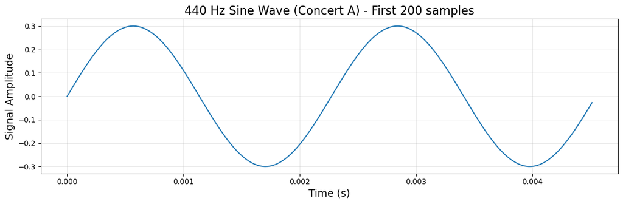

```
Listen to the 440 Hz tone:
```

[interactive chart not shown]

```python
# Generate 440 Hz tone (Concert A)
tone_A, t = generate_tone(440)

# Note to students: We only plot the first 200 data points for clarity.
# The complete audio array contains 88,200 samples (2 seconds at 44,100 samples/second),
# which would be too dense to visualize clearly on a single plot.
# Feel free to experiment by changing the 200 to a different number (e.g., 100, 500, 1000)
# to see more or fewer oscillations of the sine wave.

fig, ax = plt.subplots(figsize=(12, 4))  # Makes the plot wider
ax.plot(t[:200], tone_A[:200], linewidth=1.5)
ax.set_xlabel("Time (s)", size=14)
ax.set_ylabel("Signal Amplitude", size=14)
ax.set_title("440 Hz Sine Wave (Concert A) - First 200 samples", size=16)
ax.grid(True, alpha=0.3)  # Optional: adds a light grid for easier reading

plt.tight_layout()  # Ensures labels don't get cut off
plt.show()

print("Listen to the 440 Hz tone:")
display(Audio(tone_A, rate=44100))
```

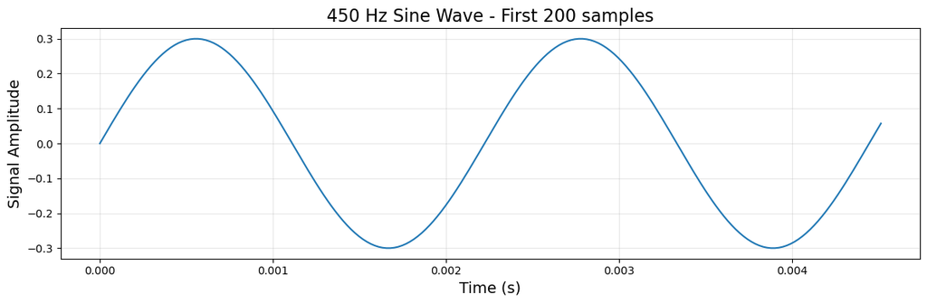

```
Listen to the 450 Hz tone:
```

[interactive chart not shown]

```python
# Generate 450 Hz t
tone_B, t = generate_tone(450)

# Note to students: We only plot the first 200 data points for clarity.
# The complete audio array contains 88,200 samples (2 seconds at 44,100 samples/second),
# which would be too dense to visualize clearly on a single plot.
# Feel free to experiment by changing the 200 to a different number (e.g., 100, 500, 1000)
# to see more or fewer oscillations of the sine wave.

fig, ax = plt.subplots(figsize=(12, 4))  # Makes the plot wider
ax.plot(t[:200], tone_B[:200], linewidth=1.5)
ax.set_xlabel("Time (s)", size=14)
ax.set_ylabel("Signal Amplitude", size=14)
ax.set_title("450 Hz Sine Wave - First 200 samples", size=16)
ax.grid(True, alpha=0.3)  # Optional: adds a light grid for easier reading

plt.tight_layout()  # Ensures labels don't get cut off
plt.show()

print("Listen to the 450 Hz tone:")
display(Audio(tone_B, rate=44100))
```

Here is the beat formed by the two tones, audio and plot.

```python
beat = tone_A - tone_B
print("Listen to the beat tone:")
display(Audio(beat, rate=44100))
```

```
Listen to the beat tone:
```

[interactive chart not shown]

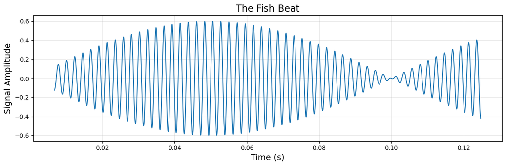

```python
fig, ax = plt.subplots(figsize=(12, 4))  # Makes the plot wider
ax.plot(t[300:5500], beat[300:5500], linewidth=1.5)
ax.set_xlabel("Time (s)", size=14)
ax.set_ylabel("Signal Amplitude", size=14)
ax.set_title("The Fish Beat", size=16)
ax.grid(True, alpha=0.3)  # Optional: adds a light grid for easier reading

plt.tight_layout()  # Ensures labels don't get cut off
plt.show()
```

I added some guitar tones.

```python
low_E, t = generate_tone(82.41)
print("Low E-string on guitar:")
display(Audio(low_E, rate=44100))
```

```
Low E-string on guitar:
```

[interactive chart not shown]

```python
high_E, t = generate_tone(329.63)
print("high E-string on guitar:")
display(Audio(high_E, rate=44100))
```

```
high E-string on guitar:
```

[interactive chart not shown]